# Distributions

Often there is information to be found in the way cases differ one from the other.

A **distribution** is a representation of the patterns of spread of the cases.

## One variable

### Categorical: how many cases at each level?

Order: help the eye

### Quantitative

No discrete levels. The fundamental display is **density**

Show some densities.

## Two or more variables: Displaying relationships

## A distribution template

### Aesthetics: 1, 2, or three variables

- `x =` The first variable: *always!*
- `y =` The *count* or *density* or another variable
- `group =` or `fill =` or `color =` Still another variable

### Facets

One or two more categorical variables

- `facet_wrap( ~ var)`
- `facet_grid(var1 ~ var2)`

## Variable types

interval —- ordered —– categorical

1. Quantitative: a natural order and interval
2. Ordinal: a natural order but not an interval
3. Categorical: no natural order

## Order

The different levels of the variable have a natural order; it’s natural to say that one level is higher than another or that a level is in-between two other levels.

- Temperature
- Age
- Likert scale (strongly disagree, disagree, neutral, …)
- Income bracket, e.g. 0-25K, 25K-40K, 40K-75K, 75K-150K
- Numerical scale, e.g. pain level of 1 to 10
- but not, e.g. Language, Nationality, …

## Interval

For variables with a natural order, does the interval between levels have a specific meaning?

- Temperature: Yes
- Age: Yes
- Likert scale: not really, but sometimes assumed
- Income bracket: No
- Language: No! (It’s not even ordered!)

## NHANES

`NHANES` package has the `NHANES` data table

### Categorical variables:

- `Gender`: no order (therefore not interval)
- `Education`: ordered but not interval
- `SexOrientation`: not really ordered (therefore not interval)
- `Work`: not really ordered (therefore not interval)
- `MaritalStatus`: no order (therefore not interval)
- `HHIncome`: ordered but not interval

### Quantitative variables

- `UrineVol1` ordered and interval
- `Age`: ordered and interval

## Single variables

### Interval (hence ordered) — use density

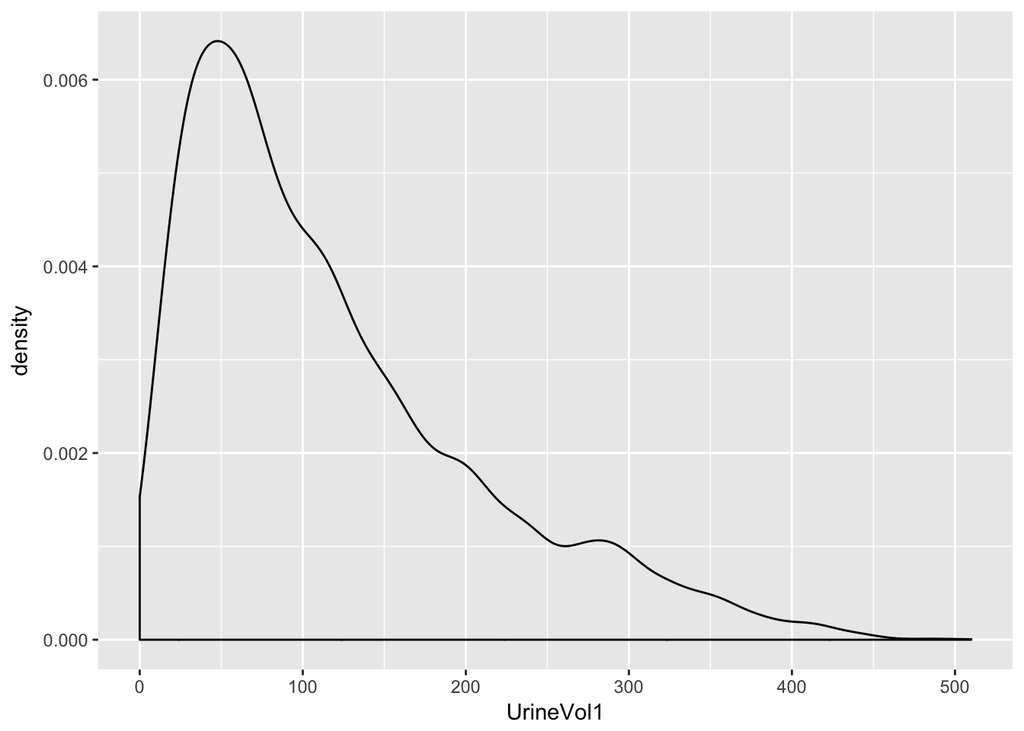

But respect the order if there is one.

1. Quantitative: a natural order and interval
2. Ordinal: a natural order but not an interval
3. Categorical: no natural order

### Two variables

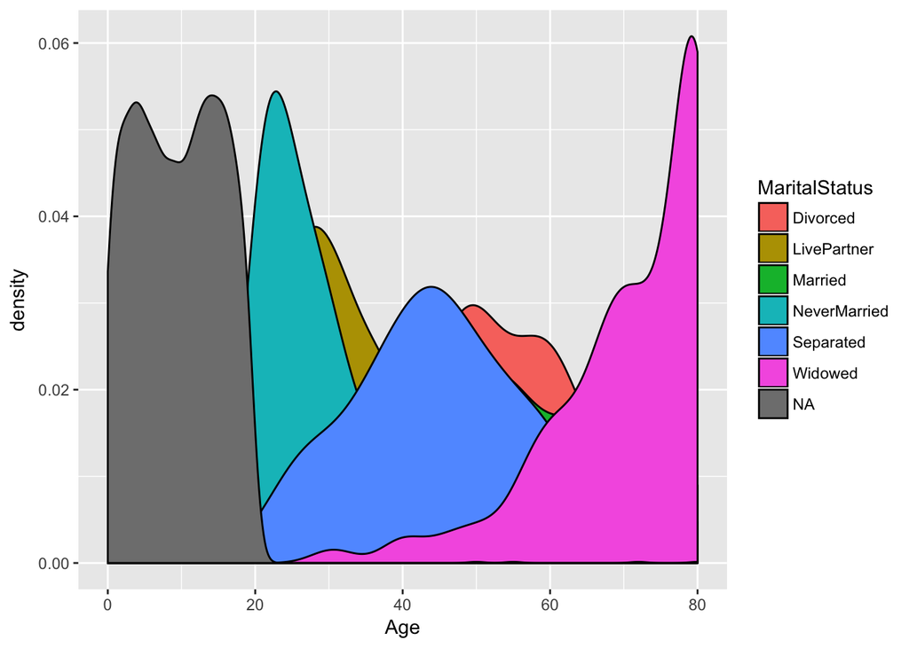

How could you make this better?

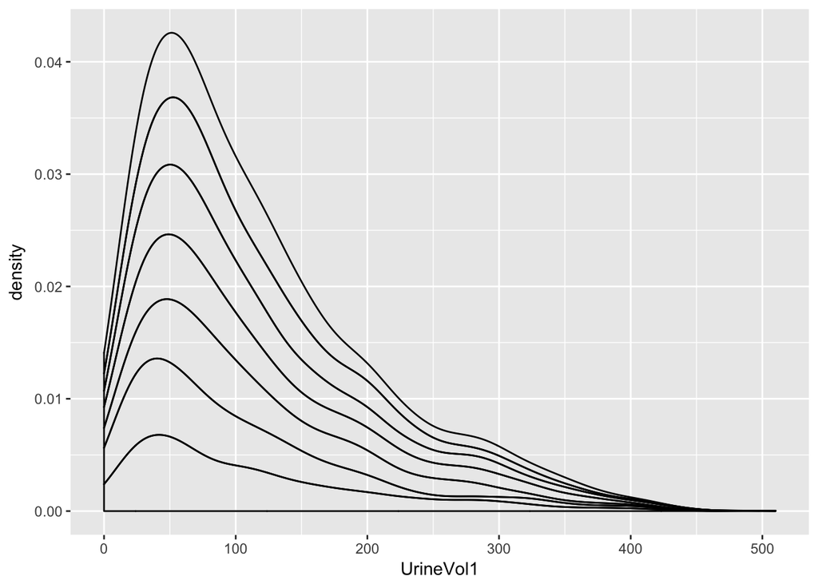

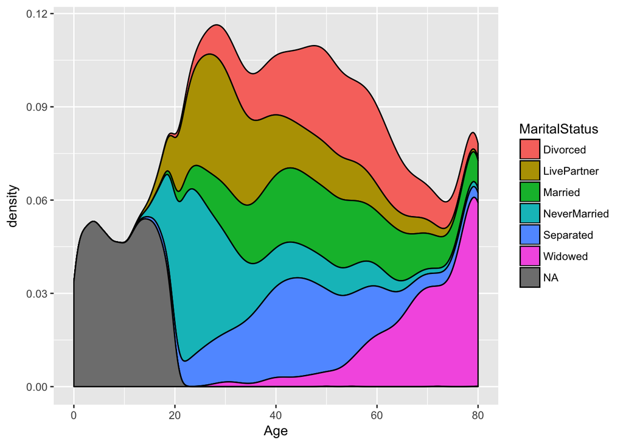

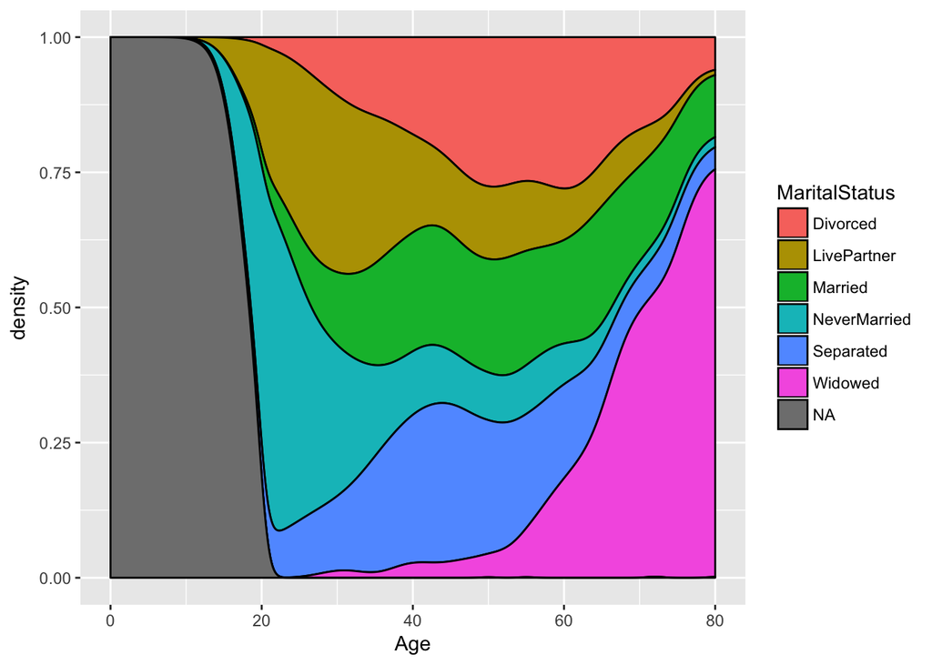

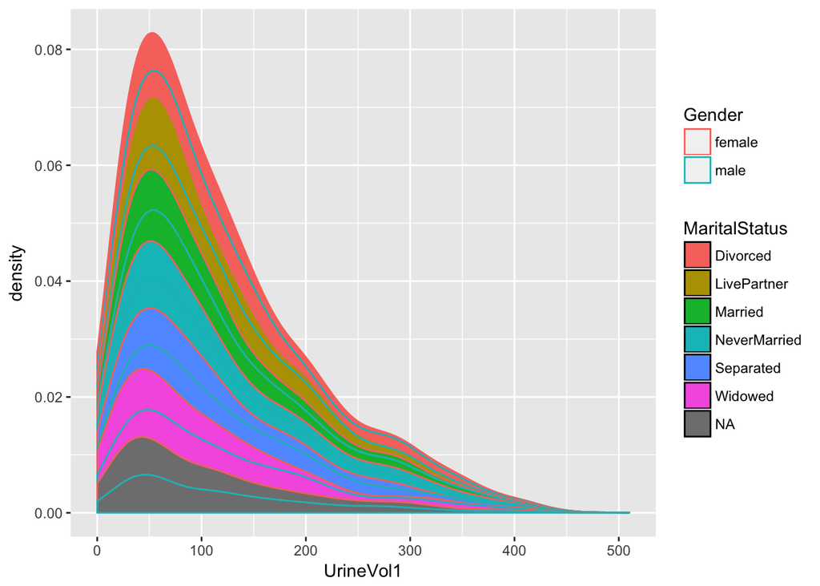

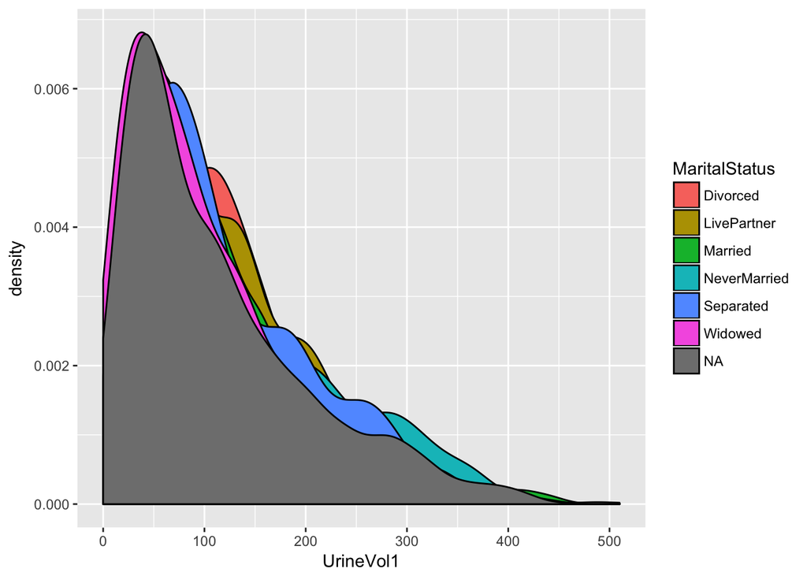

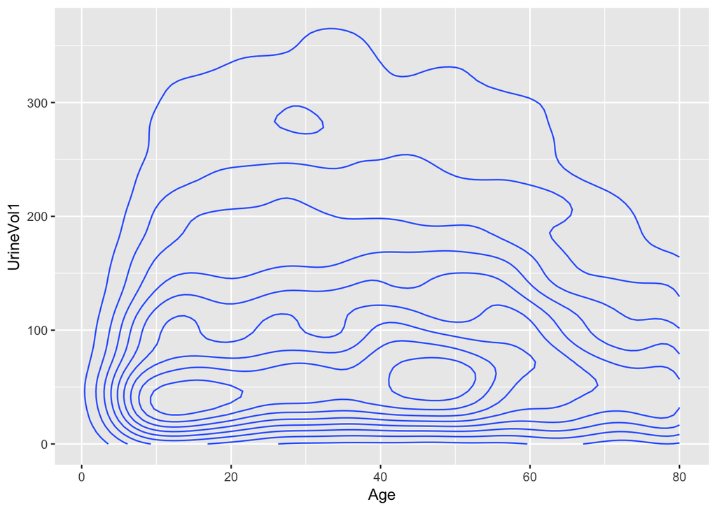

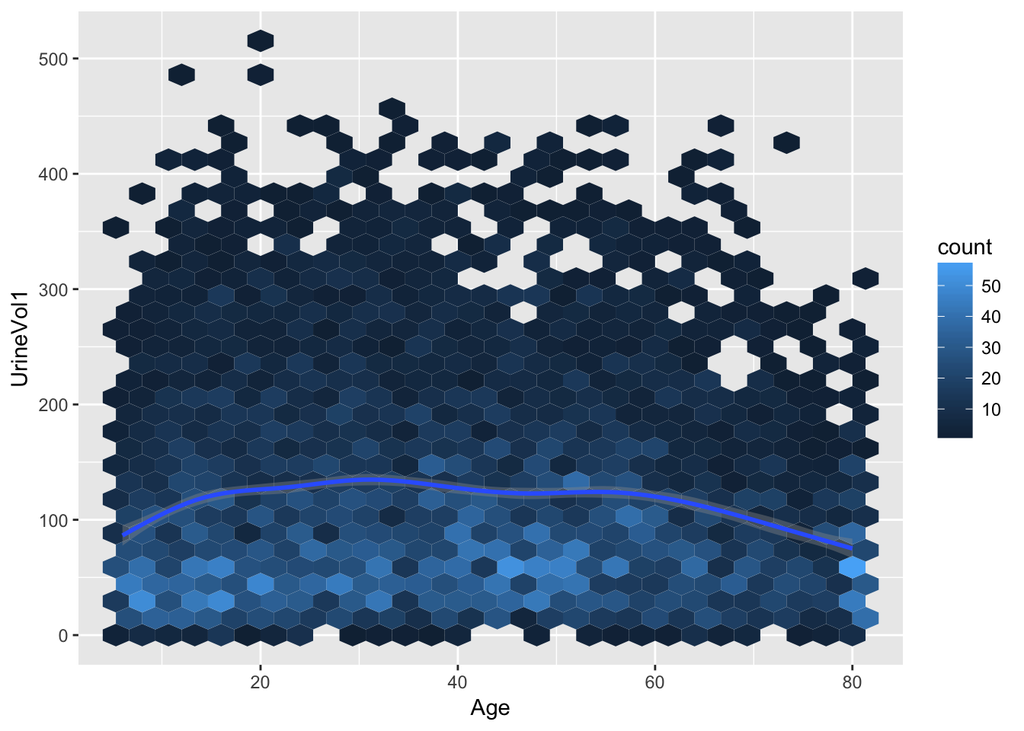